# FINTECH Final Project - Bank Marketing Classification

**Course:** `[2025-2026] - 055643 - FINTECH`  
**Student:** Salvatore Mariano Librici  
**Email:** salvatoremariano.librici@mail.polimi.it  
**Dataset:** `Dataset4.csv` - Bank Marketing

## Project goal

The goal of this notebook is to build a machine learning pipeline to estimate the probability that a client subscribes to a bank term deposit after a direct marketing campaign.

The work is structured as follows:

1. Data loading and quality checks
2. Exploratory Data Analysis
3. Preprocessing
4. Baseline model
5. Logistic Regression
6. Random Forest
7. Model comparison
8. Feature selection
9. Interpretability
10. Final business conclusions

The notebook documents the methodology, implementation choices, model results, and business interpretation required for the assignment.

```python
# Mount Google Drive
from google.colab import drive
drive.mount('/content/drive')
```

## 0. Colab setup

Expected dataset path:

```
/content/[2025-2026] - 055643 - FINTECH - PROJECT/Dataset4.csv
```

If the dataset is directly uploaded into Colab, the notebook also tries:

```
/content/Dataset4.csv
```

```python
# ============================================================
# 0. COLAB SETUP
# ============================================================

import os
from pathlib import Path

PROJECT_FOLDER = "/content/[2025-2026] - 055643 - FINTECH - PROJECT"
DATASET_NAME = "Dataset4.csv"

DATASET_PATH = os.path.join(PROJECT_FOLDER, DATASET_NAME)

# Fallback if the file is uploaded directly to /content
if not os.path.exists(DATASET_PATH):
    DATASET_PATH = f"/content/{DATASET_NAME}"

# Fallback if the file is uploaded to /content/content
if not os.path.exists(DATASET_PATH):
    DATASET_PATH = f"/content/content/{DATASET_NAME}"

# Fallback for Google Drive path
if not os.path.exists(DATASET_PATH):
    DATASET_PATH = f"/content/drive/MyDrive/[2025-2026] - 055643 - FINTECH - PROJECT/content/{DATASET_NAME}"

print("Dataset path used:", DATASET_PATH)
print("File exists:", os.path.exists(DATASET_PATH))
```

```
Dataset path used: /content/drive/MyDrive/[2025-2026] - 055643 - FINTECH - PROJECT/content/Dataset4.csv
File exists: True
```

## 1. Import libraries

Libraries for data manipulation, visualization, preprocessing, modeling, evaluation and interpretability.

```python
# ============================================================
# 1. IMPORT LIBRARIES
# ============================================================

import warnings
warnings.filterwarnings("ignore")

import pandas as pd
import numpy as np

import matplotlib.pyplot as plt
import seaborn as sns

from sklearn.model_selection import train_test_split, GridSearchCV
from sklearn.compose import ColumnTransformer
from sklearn.preprocessing import StandardScaler, OneHotEncoder
from sklearn.pipeline import Pipeline

from sklearn.dummy import DummyClassifier
from sklearn.linear_model import LogisticRegression
from sklearn.ensemble import RandomForestClassifier

from sklearn.metrics import (
    accuracy_score,
    balanced_accuracy_score,
    precision_score,
    recall_score,
    f1_score,
    roc_auc_score,
    average_precision_score,
    confusion_matrix,
    classification_report,
    RocCurveDisplay,
    PrecisionRecallDisplay
)

from sklearn.inspection import permutation_importance

try:
    import shap
    SHAP_AVAILABLE = True
except ImportError:
    SHAP_AVAILABLE = False
    print("SHAP is not installed. Run this cell if needed: !pip install shap")

sns.set_theme(style="whitegrid")
plt.rcParams["figure.figsize"] = (10, 6)
plt.rcParams["axes.titlesize"] = 14
plt.rcParams["axes.labelsize"] = 12

RANDOM_STATE = 42

print("Libraries loaded successfully.")
```

```
Libraries loaded successfully.
```

## 2. Load dataset

We load the dataset and inspect the first rows.

```python
# ============================================================
# 2. LOAD DATASET
# ============================================================

df = pd.read_csv(DATASET_PATH, sep=';')

display(df.head())
print(f"Dataset shape: {df.shape[0]} rows and {df.shape[1]} columns")
```

|  | age | job | marital | education | default | balance | housing | loan | contact | day | month | duration | campaign | pdays | previous | poutcome | y |
| --- | --- | --- | --- | --- | --- | --- | --- | --- | --- | --- | --- | --- | --- | --- | --- | --- | --- |
| 0 | 58 | management | married | tertiary | no | 2143 | yes | no | unknown | 5 | may | 261 | 1 | -1 | 0 | unknown | no |
| 1 | 44 | technician | single | secondary | no | 29 | yes | no | unknown | 5 | may | 151 | 1 | -1 | 0 | unknown | no |
| 2 | 33 | entrepreneur | married | secondary | no | 2 | yes | yes | unknown | 5 | may | 76 | 1 | -1 | 0 | unknown | no |
| 3 | 47 | blue-collar | married | unknown | no | 1506 | yes | no | unknown | 5 | may | 92 | 1 | -1 | 0 | unknown | no |
| 4 | 33 | unknown | single | unknown | no | 1 | no | no | unknown | 5 | may | 198 | 1 | -1 | 0 | unknown | no |

```
Dataset shape: 45211 rows and 17 columns
```

## 3. Initial data overview

We inspect:

- column names
- data types
- number of non-null observations
- descriptive statistics

This gives a first understanding of numerical and categorical predictors.

```python
# ============================================================
# 3. INITIAL DATA OVERVIEW
# ============================================================

print("Column names:")
print(df.columns.tolist())

print("\nData types and non-null counts:")
df.info()
```

```
Column names:
['age', 'job', 'marital', 'education', 'default', 'balance', 'housing', 'loan', 'contact', 'day', 'month', 'duration', 'campaign', 'pdays', 'previous', 'poutcome', 'y']

Data types and non-null counts:
<class 'pandas.core.frame.DataFrame'>
RangeIndex: 45211 entries, 0 to 45210
Data columns (total 17 columns):
 #   Column     Non-Null Count  Dtype
---  ------     --------------  -----
 0   age        45211 non-null  int64
 1   job        45211 non-null  object
 2   marital    45211 non-null  object
 3   education  45211 non-null  object
 4   default    45211 non-null  object
 5   balance    45211 non-null  int64
 6   housing    45211 non-null  object
 7   loan       45211 non-null  object
 8   contact    45211 non-null  object
 9   day        45211 non-null  int64
 10  month      45211 non-null  object
 11  duration   45211 non-null  int64
 12  campaign   45211 non-null  int64
 13  pdays      45211 non-null  int64
 14  previous   45211 non-null  int64
 15  poutcome   45211 non-null  object
 16  y          45211 non-null  object
dtypes: int64(7), object(10)
memory usage: 5.9+ MB
```

```python
# Descriptive statistics for numerical variables
display(df.describe().T)
```

|  | count | mean | std | min | 25% | 50% | 75% | max |
| --- | --- | --- | --- | --- | --- | --- | --- | --- |
| age | 45211.0 | 40.936210 | 10.618762 | 18.0 | 33.0 | 39.0 | 48.0 | 95.0 |
| balance | 45211.0 | 1362.272058 | 3044.765829 | -8019.0 | 72.0 | 448.0 | 1428.0 | 102127.0 |
| day | 45211.0 | 15.806419 | 8.322476 | 1.0 | 8.0 | 16.0 | 21.0 | 31.0 |
| duration | 45211.0 | 258.163080 | 257.527812 | 0.0 | 103.0 | 180.0 | 319.0 | 4918.0 |
| campaign | 45211.0 | 2.763841 | 3.098021 | 1.0 | 1.0 | 2.0 | 3.0 | 63.0 |
| pdays | 45211.0 | 40.197828 | 100.128746 | -1.0 | -1.0 | -1.0 | -1.0 | 871.0 |
| previous | 45211.0 | 0.580323 | 2.303441 | 0.0 | 0.0 | 0.0 | 0.0 | 275.0 |

```python
# Descriptive statistics for categorical variables
display(df.describe(include="object").T)
```

|  | count | unique | top | freq |
| --- | --- | --- | --- | --- |
| job | 45211 | 12 | blue-collar | 9732 |
| marital | 45211 | 3 | married | 27214 |
| education | 45211 | 4 | secondary | 23202 |
| default | 45211 | 2 | no | 44396 |
| housing | 45211 | 2 | yes | 25130 |
| loan | 45211 | 2 | no | 37967 |
| contact | 45211 | 3 | cellular | 29285 |
| month | 45211 | 12 | may | 13766 |
| poutcome | 45211 | 4 | unknown | 36959 |
| y | 45211 | 2 | no | 39922 |

### Initial observations

The dataset contains 45,211 observations and 17 variables. The target variable is `y`, indicating whether the client subscribed to the term deposit. The predictors include both numerical variables, such as `age`, `balance`, `duration`, `campaign`, `pdays`, and `previous`, and categorical variables, such as `job`, `marital`, `education`, `contact`, `month`, and `poutcome`.

Some categorical variables contain the value `unknown`. In this analysis, these values are initially kept as separate categories because missing or unavailable information may itself be informative in a banking context.

## 4. Data quality checks

Before modeling, we check:

1. missing values
2. duplicate rows
3. `"unknown"` values in categorical variables
4. basic target consistency

```python
# ============================================================
# 4. DATA QUALITY CHECKS
# ============================================================

missing_values = df.isnull().sum().sort_values(ascending=False)
missing_values = missing_values[missing_values > 0]

print("Missing values:")
display(missing_values if len(missing_values) > 0 else "No missing values found.")
```

```
Missing values:
```

```
'No missing values found.'
```

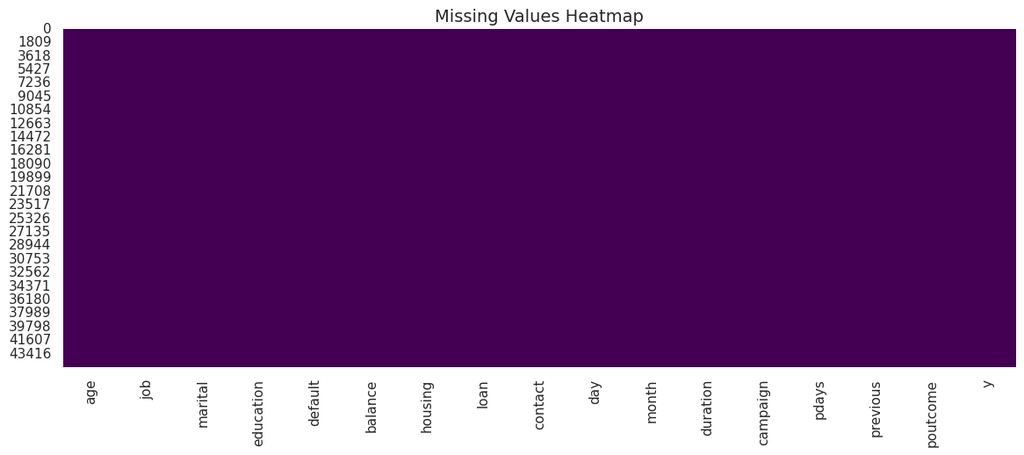

```python
plt.figure(figsize=(14, 5))
sns.heatmap(df.isnull(), cbar=False, cmap="viridis")
plt.title("Missing Values Heatmap")
plt.show()
```

```python
duplicates = df.duplicated().sum()
print("Number of duplicated rows:", duplicates)
```

```
Number of duplicated rows: 0
```

```python
categorical_columns = df.select_dtypes(include="object").columns.tolist()

unknown_summary = {}
for col in categorical_columns:
    unknown_summary[col] = (df[col] == "unknown").sum()

unknown_summary = pd.Series(unknown_summary).sort_values(ascending=False)
display(unknown_summary[unknown_summary > 0])
```

|  | 0 |
| --- | --- |
| poutcome | 36959 |
| contact | 13020 |
| education | 1857 |
| job | 288 |

**dtype:** int64

### Data quality interpretation

The dataset does not require major structural corrections before modeling. The value `unknown` is kept as a valid category rather than being removed, since it may capture relevant information about missing customer or campaign data.

Exact duplicate records and missing values are checked before the modeling phase. The preprocessing strategy therefore focuses mainly on target encoding, numerical scaling where needed, and one-hot encoding of categorical predictors.

## 5. Target variable analysis

The target variable is:

- `yes`: client subscribed the term deposit
- `no`: client did not subscribe the term deposit

We inspect class balance before selecting metrics and models.

```python
# ============================================================
# 5. TARGET VARIABLE ANALYSIS
# ============================================================

target_counts = df["y"].value_counts()
target_percentages = (df["y"].value_counts(normalize=True) * 100).round(2)

target_summary = pd.DataFrame({
    "count": target_counts,
    "percentage": target_percentages
})

display(target_summary)
```

| y | count | percentage |
| --- | --- | --- |
| no | 39922 | 88.3 |
| yes | 5289 | 11.7 |

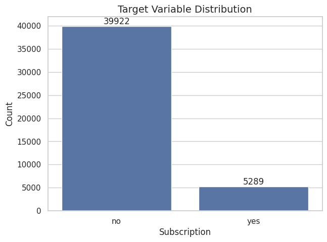

```python
plt.figure(figsize=(7, 5))
ax = sns.countplot(data=df, x="y", order=target_counts.index)

for container in ax.containers:
    ax.bar_label(container)

plt.title("Target Variable Distribution")
plt.xlabel("Subscription")
plt.ylabel("Count")
plt.show()
```

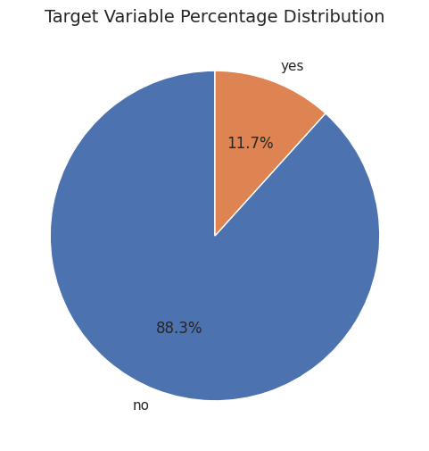

```python
plt.figure(figsize=(6, 6))
plt.pie(
    target_counts,
    labels=target_counts.index,
    autopct="%1.1f%%",
    startangle=90
)
plt.title("Target Variable Percentage Distribution")
plt.show()
```

### Target interpretation

The target variable is strongly imbalanced: most clients did not subscribe to the term deposit. In the dataset, 39,922 observations belong to the `no` class and 5,289 observations belong to the `yes` class.

For this reason, accuracy alone is not sufficient to evaluate model quality. The analysis also considers balanced accuracy, precision, recall, F1-score, ROC-AUC and PR-AUC.

## 6. Numerical feature analysis

We inspect the distribution of numerical variables to detect skewness, extreme values and possible scaling needs.

```python
# ============================================================
# 6. NUMERICAL FEATURE ANALYSIS
# ============================================================

num_cols = df.select_dtypes(include=np.number).columns.tolist()
cat_cols = [col for col in df.select_dtypes(include="object").columns.tolist() if col != "y"]

print("Numerical columns:", num_cols)
print("Categorical columns:", cat_cols)
```

```
Numerical columns: ['age', 'balance', 'day', 'duration', 'campaign', 'pdays', 'previous']
Categorical columns: ['job', 'marital', 'education', 'default', 'housing', 'loan', 'contact', 'month', 'poutcome']
```

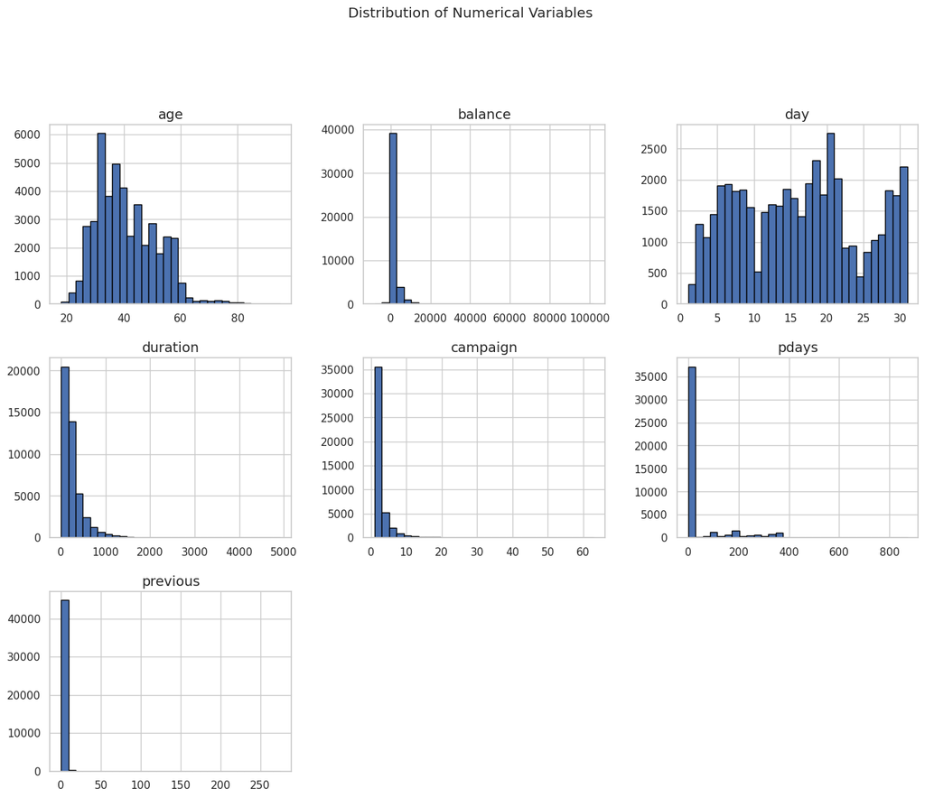

```python
df[num_cols].hist(figsize=(16, 12), bins=30, edgecolor="black")
plt.suptitle("Distribution of Numerical Variables", y=1.02)
plt.show()
```

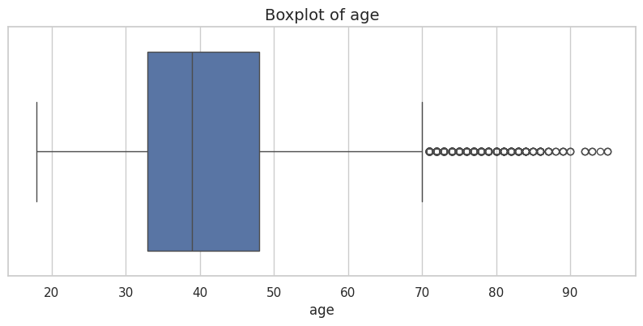

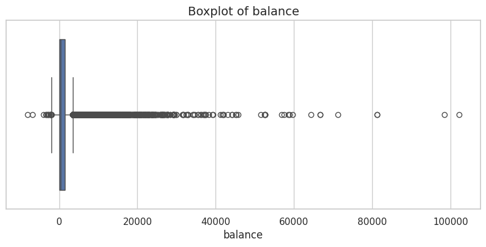

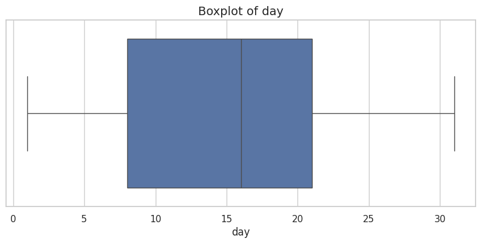

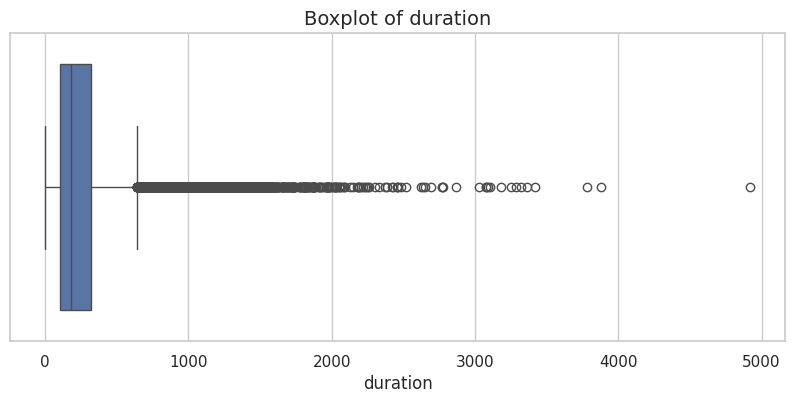

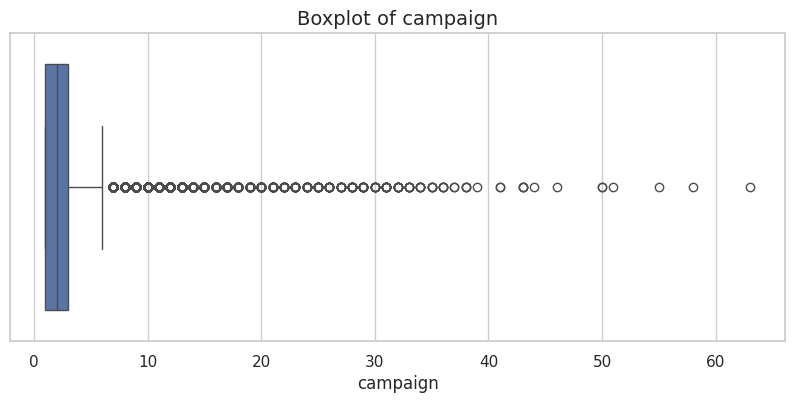

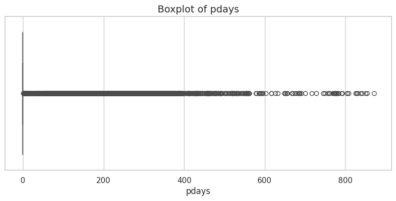

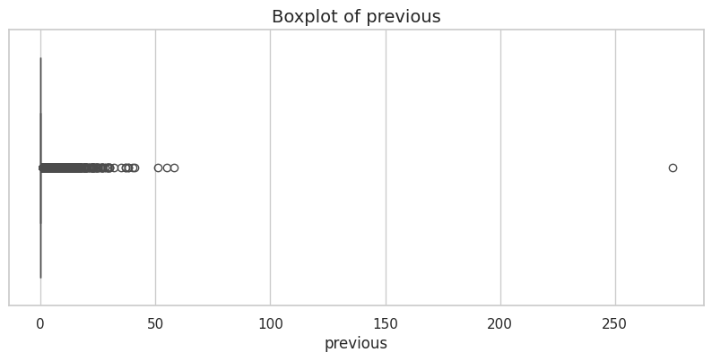

```python
for col in num_cols:
    plt.figure(figsize=(10, 4))
    sns.boxplot(x=df[col])
    plt.title(f"Boxplot of {col}")
    plt.show()
```

```python
skewness = df[num_cols].skew().sort_values(ascending=False)
display(pd.DataFrame({"skewness": skewness}))
```

|  | skewness |
| --- | --- |
| previous | 41.846454 |
| balance | 8.360308 |
| campaign | 4.898650 |
| duration | 3.144318 |
| pdays | 2.615715 |
| age | 0.684818 |
| day | 0.093079 |

### Numerical feature interpretation

Several numerical variables show skewed distributions and potential outliers, especially financial and campaign-related variables such as `balance`, `duration`, and `campaign`. These patterns are expected in customer and marketing data.

Scaling is applied for Logistic Regression because the model is sensitive to the magnitude of numerical predictors. Random Forest is less sensitive to scaling, so numerical variables are passed through directly for the tree-based model.

## 7. Numerical variables vs target

We compare numerical features across subscribed and non-subscribed clients.

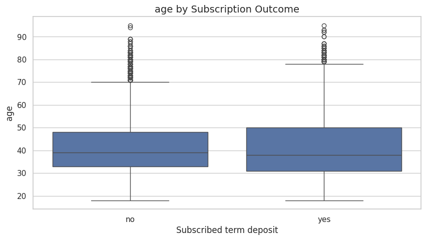

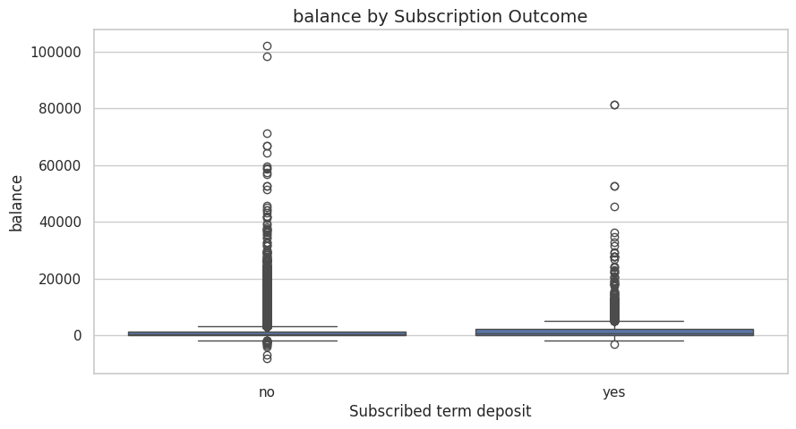

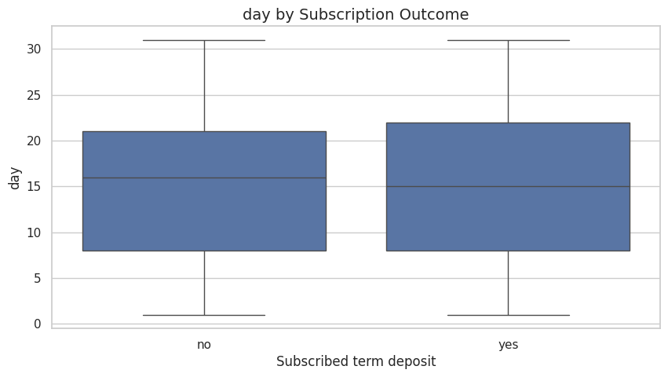

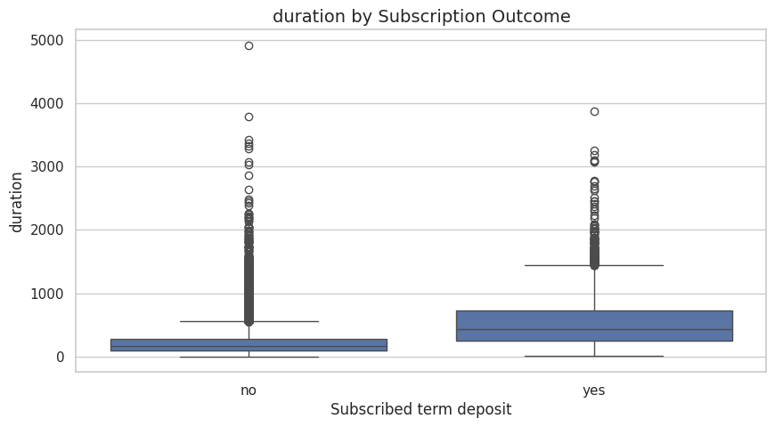

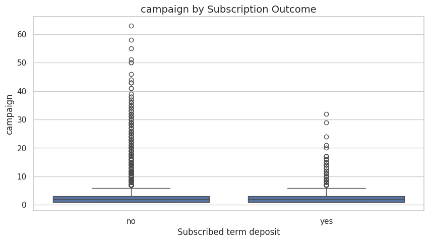

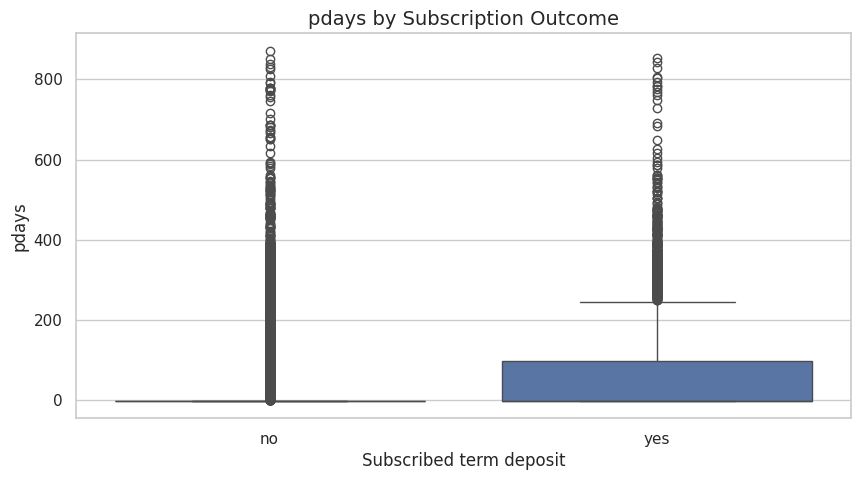

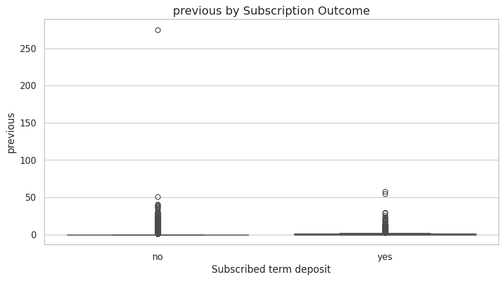

```python
# ============================================================
# 7. NUMERICAL VARIABLES VS TARGET
# ============================================================

for col in num_cols:
    plt.figure(figsize=(10, 5))
    sns.boxplot(data=df, x="y", y=col)
    plt.title(f"{col} by Subscription Outcome")
    plt.xlabel("Subscribed term deposit")
    plt.ylabel(col)
    plt.show()
```

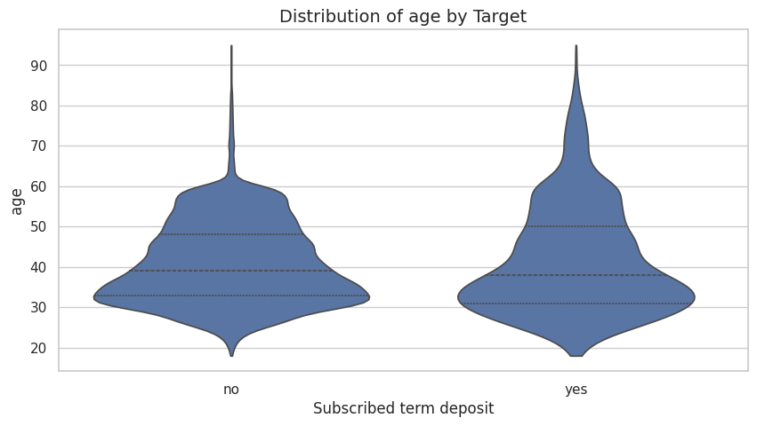

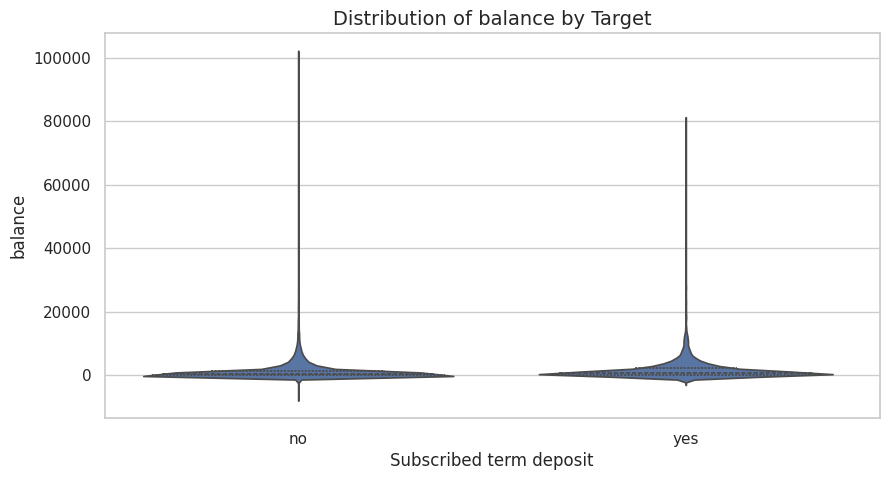

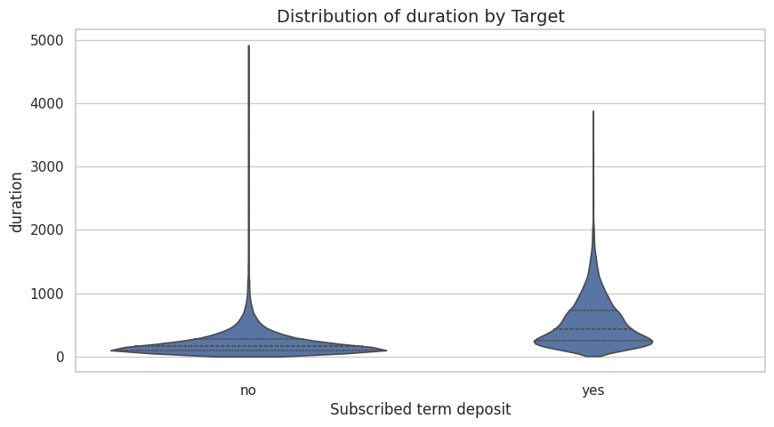

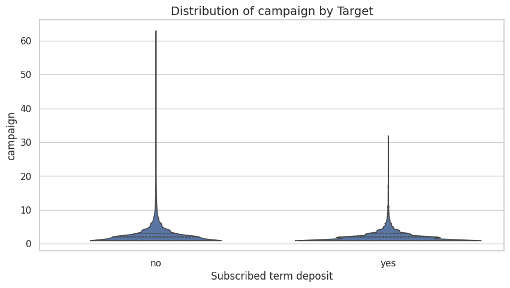

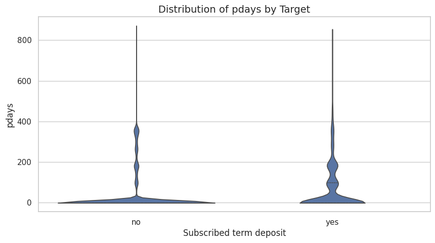

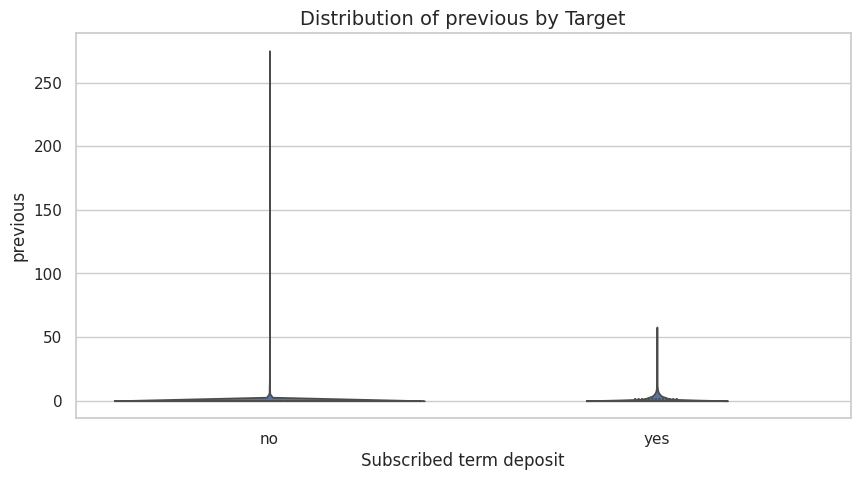

```python
selected_num_cols = [col for col in ["age", "balance", "duration", "campaign", "pdays", "previous"] if col in df.columns]

for col in selected_num_cols:
    plt.figure(figsize=(10, 5))
    sns.violinplot(data=df, x="y", y=col, inner="quartile", cut=0)
    plt.title(f"Distribution of {col} by Target")
    plt.xlabel("Subscribed term deposit")
    plt.ylabel(col)
    plt.show()
```

```python
median_by_target = df.groupby("y")[num_cols].median().T
display(median_by_target)
```

| y | no | yes |
| --- | --- | --- |
| age | 39.0 | 38.0 |
| balance | 417.0 | 733.0 |
| day | 16.0 | 15.0 |
| duration | 164.0 | 426.0 |
| campaign | 2.0 | 2.0 |
| pdays | -1.0 | -1.0 |
| previous | 0.0 | 0.0 |

### Important methodological note on `duration`

The variable `duration` represents the duration of the last contact.

It is usually very predictive because longer calls are naturally associated with higher subscription probability. However, it is only known after the call occurs.

Therefore:

- it is useful if the goal is to predict the final result after a call;
- it may be problematic if the goal is to decide whom to call before the campaign.

For robustness, this notebook includes an optional comparison with and without `duration`.

## 8. Categorical feature analysis

We analyze categorical variables using both frequency tables and subscription rates.

```python
# ============================================================
# 8. CATEGORICAL FEATURE ANALYSIS
# ============================================================

for col in cat_cols:
    print(f"\nColumn: {col}")
    display(df[col].value_counts().to_frame("count").head(20))
```

```
Column: job
```

| job | count |
| --- | --- |
| blue-collar | 9732 |
| management | 9458 |
| technician | 7597 |
| admin. | 5171 |
| services | 4154 |
| retired | 2264 |
| self-employed | 1579 |
| entrepreneur | 1487 |
| unemployed | 1303 |
| housemaid | 1240 |
| student | 938 |
| unknown | 288 |

```
Column: marital
```

| marital | count |
| --- | --- |
| married | 27214 |
| single | 12790 |
| divorced | 5207 |

```
Column: education
```

| education | count |
| --- | --- |
| secondary | 23202 |
| tertiary | 13301 |
| primary | 6851 |
| unknown | 1857 |

```
Column: default
```

| default | count |
| --- | --- |
| no | 44396 |
| yes | 815 |

```
Column: housing
```

| housing | count |
| --- | --- |
| yes | 25130 |
| no | 20081 |

```
Column: loan
```

| loan | count |
| --- | --- |
| no | 37967 |
| yes | 7244 |

```
Column: contact
```

| contact | count |
| --- | --- |
| cellular | 29285 |
| unknown | 13020 |
| telephone | 2906 |

```
Column: month
```

| month | count |
| --- | --- |
| may | 13766 |
| jul | 6895 |
| aug | 6247 |
| jun | 5341 |
| nov | 3970 |
| apr | 2932 |
| feb | 2649 |
| jan | 1403 |
| oct | 738 |
| sep | 579 |
| mar | 477 |
| dec | 214 |

```
Column: poutcome
```

| poutcome | count |
| --- | --- |
| unknown | 36959 |
| failure | 4901 |
| other | 1840 |
| success | 1511 |

```python
def plot_subscription_rate_by_category(data, column, target="y", min_count=0):
    # Plot subscription rate by category.
    temp = data.copy()

    counts = temp[column].value_counts()
    valid_categories = counts[counts >= min_count].index
    temp = temp[temp[column].isin(valid_categories)]

    rate = (
        temp.groupby(column)[target]
        .apply(lambda x: (x == "yes").mean())
        .sort_values(ascending=False)
    )

    count = temp[column].value_counts().loc[rate.index]

    result = pd.DataFrame({
        "subscription_rate": rate,
        "count": count
    })

    plt.figure(figsize=(12, 5))
    sns.barplot(x=result.index, y=result["subscription_rate"])
    plt.title(f"Subscription Rate by {column}")
    plt.ylabel("Subscription rate")
    plt.xlabel(column)
    plt.xticks(rotation=45, ha="right")
    plt.show()

    display(result)
```